# Practical Machine Learning - Prediction Assignment

Nazar Kalinichenko

2023-01-29

# Libraries used

```r
library(caret); library(ggplot2); library(ggcorrplot)
```

# Preparation

## Get the data

First of all we should set the working directory. I am going to set my at “Practical Machine Learning” folder in the home directory.

```r
setwd("~/Practical Machine Learning")
```

Next, put the data files in the folder we created and read them in the R environment.

```r
train <- read.csv("pml-training.csv")
test <- read.csv("pml-testing.csv")
```

Let’s see the data (first 5 columns) to make sure everything loaded nicely.

```r
head(train[, 1:5])
```

```
##   X user_name raw_timestamp_part_1 raw_timestamp_part_2   cvtd_timestamp
## 1 1  carlitos           1323084231               788290 05/12/2011 11:23
## 2 2  carlitos           1323084231               808298 05/12/2011 11:23
## 3 3  carlitos           1323084231               820366 05/12/2011 11:23
## 4 4  carlitos           1323084232               120339 05/12/2011 11:23
## 5 5  carlitos           1323084232               196328 05/12/2011 11:23
## 6 6  carlitos           1323084232               304277 05/12/2011 11:23
```

```r
head(test[, 1:5])
```

```
##   X user_name raw_timestamp_part_1 raw_timestamp_part_2   cvtd_timestamp
## 1 1     pedro           1323095002               868349 05/12/2011 14:23
## 2 2    jeremy           1322673067               778725 30/11/2011 17:11
## 3 3    jeremy           1322673075               342967 30/11/2011 17:11
## 4 4    adelmo           1322832789               560311 02/12/2011 13:33
## 5 5    eurico           1322489635               814776 28/11/2011 14:13
## 6 6    jeremy           1322673149               510661 30/11/2011 17:12
```

```r
dim(train); dim(test)
```

```
## [1] 19622   160
```

```
## [1]  20 160
```

## Preprocess the data

### Near zero variance

The next step is to pre-process the data. First, I will get rid of near zero variance variables, as they are approx. constant and do not contribute to the variable we are interested in.

Let’s see some info about columns that have near zero variance.

```r
nzv_metrics <- nearZeroVar(train, saveMetrics = TRUE)
head(nzv_metrics, 10)
```

```
##                      freqRatio percentUnique zeroVar   nzv
## X                     1.000000  100.00000000   FALSE FALSE
## user_name             1.100679    0.03057792   FALSE FALSE
## raw_timestamp_part_1  1.000000    4.26562022   FALSE FALSE
## raw_timestamp_part_2  1.000000   85.53154622   FALSE FALSE
## cvtd_timestamp        1.000668    0.10192641   FALSE FALSE
## new_window           47.330049    0.01019264   FALSE  TRUE
## num_window            1.000000    4.37264295   FALSE FALSE
## roll_belt             1.101904    6.77810621   FALSE FALSE
## pitch_belt            1.036082    9.37722964   FALSE FALSE
## yaw_belt              1.058480    9.97349913   FALSE FALSE
```

Now let’s delete these columns from the data. As can be seen, it has deleted 60 columns.

```r
nzv <- nearZeroVar(train)
train <- train[, -nzv]
test <- test[, -nzv]
dim(train); dim(test)
```

```
## [1] 19622   100
```

```
## [1]  20 100
```

### Irrelevant columns

Now I will delete the columns that clearly do not contribute to the “classe” variable. We have gotten rid of 5 more columns.

```r
irrelevant_columns <- c("X", "user_name", "raw_timestamp_part_1", "raw_timestamp_part_2", "cvtd_timestamp")
train <- train[,!names(train) %in% irrelevant_columns]
test <- test[,!names(test) %in% irrelevant_columns]
dim(train); dim(test)
```

```
## [1] 19622    95
```

```
## [1] 20 95
```

### NA values

Next up, I address the columns that have NA values by removing them. We are left with 19622 observations and 54 columns for the train set and 20 observations and 54 columns for the test set.

```r
cond <- colSums(is.na(train)) == 0
train <- train[, cond]
test <- test[, cond]
dim(train); dim(test)
```

```
## [1] 19622    54
```

```
## [1] 20 54
```

Before going into data splitting let’s quickly visualize the correlation matrix of the pre-processed dataset (“classe” column removed) with ggcorplot package.

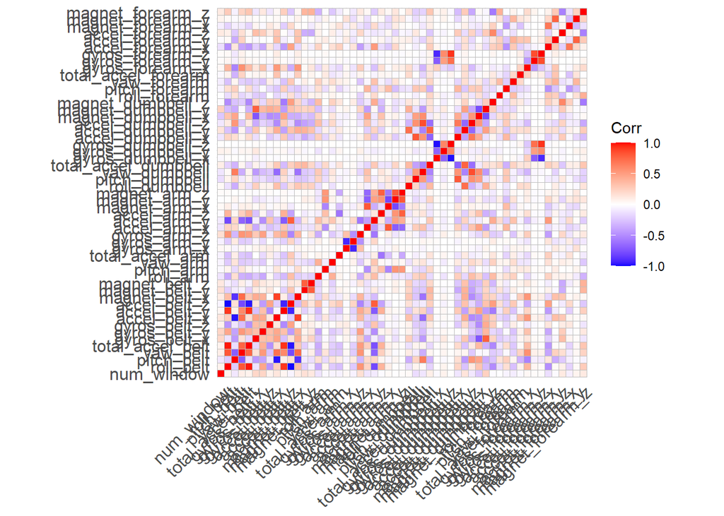

```r
ggcorrplot(cor(train[, -54]))
```

### Partition to validation set

At last, we will partition our train set into train and validation sets with 80% and 20% respectively.

```r
train_old <- train
inTrain <- createDataPartition(y=train_old$classe, p=0.80, list=FALSE)
train <- train_old[inTrain,]
validate <- train_old[-inTrain,]
dim(train)
```

```
## [1] 15699    54
```

```r
dim(validate)
```

```
## [1] 3923   54
```

# Fitting the model

The model we arg going to use will be Random Forest. It is a decently performant model for a problem of classification in ML.

## Split the data for cross-validation

We will use K-fold(10) method to split the data and use one of the folds each time to evaluating our model robustly. Then we will take the average value of our score.

```r
ctrl <- trainControl(method = "cv", number = 10)
```

## Fitting the model to the data

We fill also pass the preProcess argument to center and scale our data. The execution may take some time depending on your CPU.

```r
modelFit <- train(classe ~ ., data = train, preProcess=c("center", "scale"), method = "rf", trControl = ctrl)
modelFit
```

```
## Random Forest
##
## 15699 samples
##    53 predictor
##     5 classes: 'A', 'B', 'C', 'D', 'E'
##
## Pre-processing: centered (53), scaled (53)
## Resampling: Cross-Validated (10 fold)
## Summary of sample sizes: 14130, 14128, 14128, 14130, 14130, 14130, ...
## Resampling results across tuning parameters:
##
##   mtry  Accuracy   Kappa
##    2    0.9951587  0.9938756
##   27    0.9977069  0.9970995
##   53    0.9939491  0.9923455
##
## Accuracy was used to select the optimal model using the largest value.
## The final value used for the model was mtry = 27.
```

# Predict on the validation set

Make our prediction and get confusion matrix.

```r
predictionRF <- predict(modelFit, validate)
conf_mat <- confusionMatrix(
  as.factor(validate$classe),
  as.factor(predictionRF))
conf_mat
```

```
## Confusion Matrix and Statistics
##
##           Reference
## Prediction    A    B    C    D    E
##          A 1115    1    0    0    0
##          B    0  759    0    0    0
##          C    0    1  683    0    0
##          D    0    0    2  641    0
##          E    0    0    0    1  720
##
## Overall Statistics
##
##                Accuracy : 0.9987
##                  95% CI : (0.997, 0.9996)
##     No Information Rate : 0.2842
##     P-Value [Acc > NIR] : < 2.2e-16
##
##                   Kappa : 0.9984
##
##  Mcnemar's Test P-Value : NA
##
## Statistics by Class:
##
##                      Class: A Class: B Class: C Class: D Class: E
## Sensitivity            1.0000   0.9974   0.9971   0.9984   1.0000
## Specificity            0.9996   1.0000   0.9997   0.9994   0.9997
## Pos Pred Value         0.9991   1.0000   0.9985   0.9969   0.9986
## Neg Pred Value         1.0000   0.9994   0.9994   0.9997   1.0000
## Prevalence             0.2842   0.1940   0.1746   0.1637   0.1835
## Detection Rate         0.2842   0.1935   0.1741   0.1634   0.1835
## Detection Prevalence   0.2845   0.1935   0.1744   0.1639   0.1838
## Balanced Accuracy      0.9998   0.9987   0.9984   0.9989   0.9998
```

Let’s get our out of sample error (estimation because it is still the validation set).

```r
out_sample_error <- 1 - as.numeric(conf_mat$overall[1])
out_sample_error
```

```
## [1] 0.001274535
```

# Predict on the test set

```r
predict(modelFit, test[, -54])
```

```
##  [1] B A B A A E D B A A B C B A E E A B B B
## Levels: A B C D E
```